# Mapas

Com os dados compilados podemos portanto plotar o mapa colorindo segundo o partido.

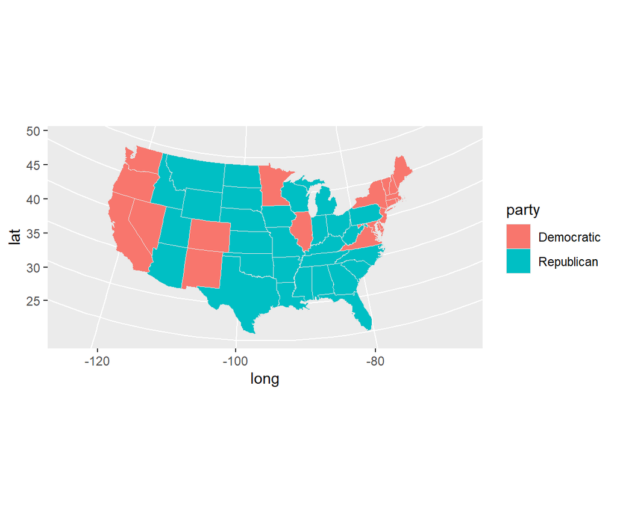

```r
p <- ggplot(data = us_states_elec,
            aes(x = long,
                y = lat,
                group = group,
                fill = party))

p + geom_polygon(color = "gray90", size = 0.1) +
    coord_map(projection = "albers", lat0 = 39, lat1 = 45)
```

Adicionando certas configurações ao tema, como as cores pre-definidas anteriormente e remover o grid.

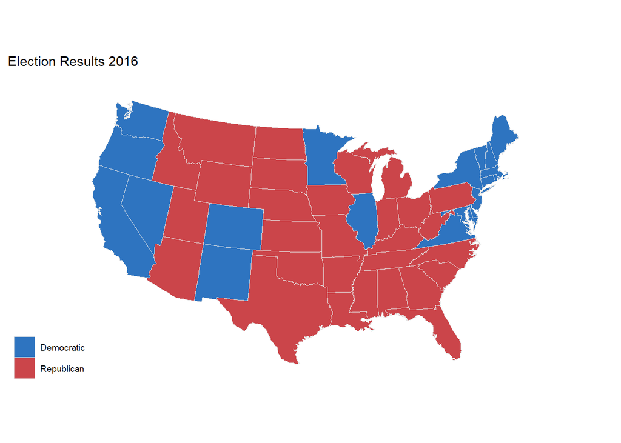

```r
theme_map <- function(base_size=9, base_family="") {
    require(grid)
    theme_bw(base_size=base_size, base_family=base_family) %+replace%
        theme(axis.line=element_blank(),
              axis.text=element_blank(),
              axis.ticks=element_blank(),
              axis.title=element_blank(),
              panel.background=element_blank(),
              panel.border=element_blank(),
              panel.grid=element_blank(),
              panel.spacing=unit(0, "lines"),
              plot.background=element_blank(),
              legend.justification = c(0,0),
              legend.position = c(0,0)
              )
}

p0 <- ggplot(data = us_states_elec,
             mapping = aes(x = long,
                           y = lat,
                           group = group,
                           fill = party))

p1 <- p0 + geom_polygon(color = "gray90", size = 0.1) +
    coord_map(projection = "albers", lat0 = 39, lat1 = 45)

p2 <- p1 + scale_fill_manual(values = party_colors) +
    labs(title = "Election Results 2016", fill = NULL)

p2 + theme_map()
```

Agora a partir deste podemos colorir utilizando outras variáveis nosso mapa, como a variável contínua da porcentagem de votos em Donald Trump.

Como por padrão a cor de mapeamento é azul, em p2 especificamos a escala manualmente através da função scale_fill_gradient().

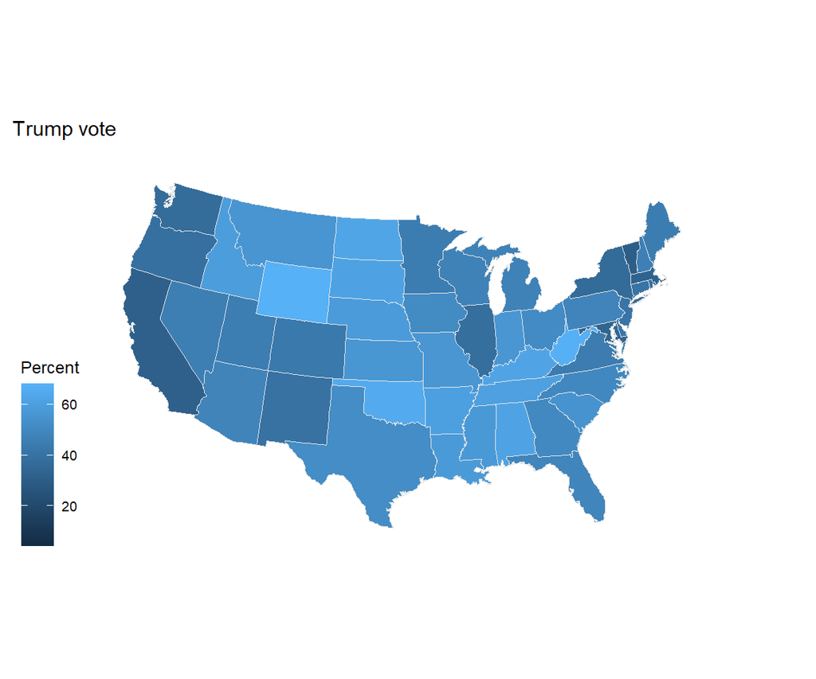

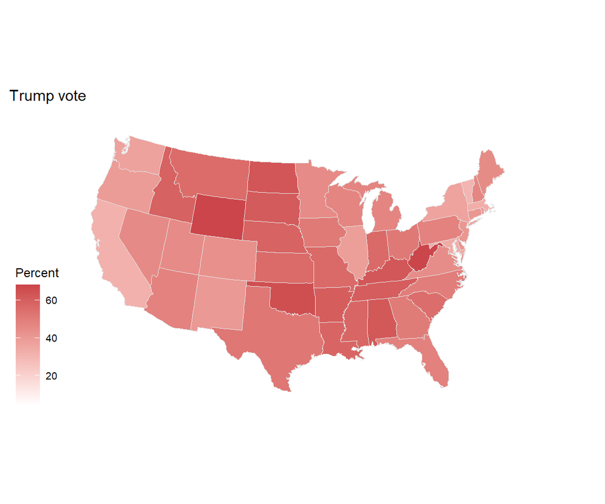

```r
p0 <- ggplot(data = us_states_elec,
             mapping = aes(x = long,
                           y = lat,
                           group = group,
                           fill = pct_trump))

p1 <- p0 + geom_polygon(color = "gray90", size = 0.1) +
    coord_map(projection = "albers", lat0 = 39, lat1 = 45)

p1 + labs(title = "Trump vote") +
  theme_map() +
  labs(fill = "Percent")

p2 <- p1 + scale_fill_gradient(low = "white",
                               high = "#CB454A") +
        labs(title = "Trump vote")

p2 + theme_map() + labs(fill = "Percent")
```

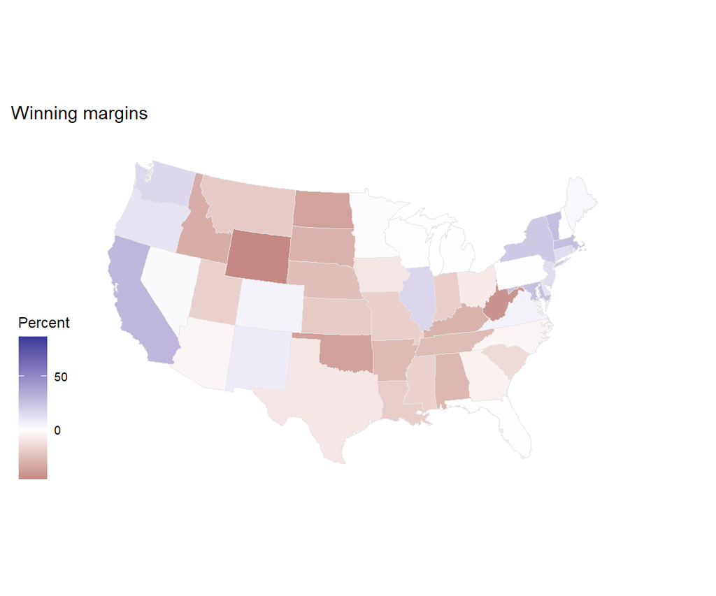

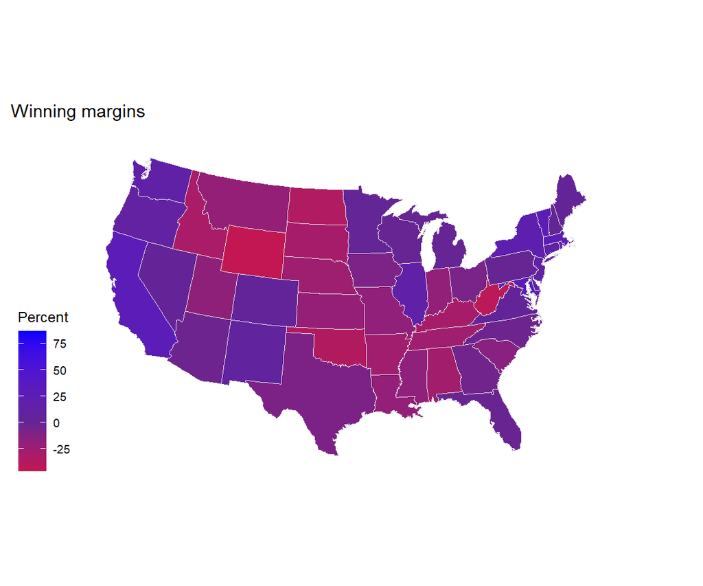

```r
p0 <- ggplot(data = us_states_elec,
             mapping = aes(x = long,
                           y = lat,
                           group = group,
                           fill = d_points))

p1 <- p0 + geom_polygon(color = "gray90", size = 0.1) +
    coord_map(projection = "albers", lat0 = 39, lat1 = 45)

p2 <- p1 + scale_fill_gradient2() +
  labs(title = "Winning margins")

p2 + theme_map() + labs(fill = "Percent")

p3 <- p1 + scale_fill_gradient2(low = "red",
                                mid = scales::muted("purple"),
                                high = "blue",
                                breaks = c(-25, 0, 25, 50, 75)) +
    labs(title = "Winning margins")

p3 + theme_map() + labs(fill = "Percent")
```

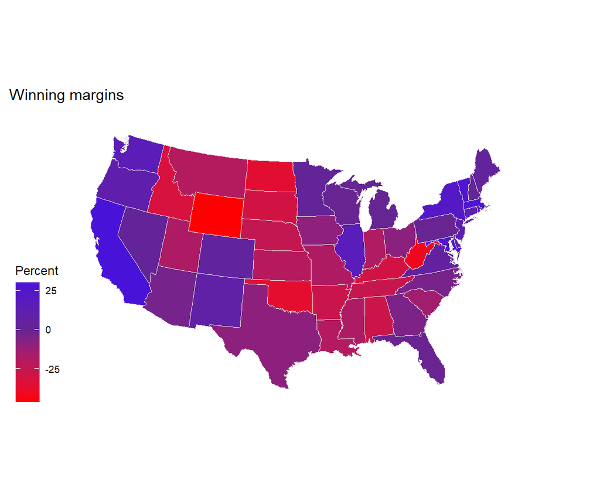

```r
p0 <- ggplot(data = subset(us_states_elec,
                           region %nin% "district of columbia"),
             aes(x = long,
                 y = lat,
                 group = group,
                 fill = d_points))

p1 <- p0 + geom_polygon(color = "gray90", size = 0.1) +
    coord_map(projection = "albers", lat0 = 39, lat1 = 45)

p2 <- p1 + scale_fill_gradient2(low = "red",
                                mid = scales::muted("purple"),
                                high = "blue") +
    labs(title = "Winning margins")

p2 + theme_map() + labs(fill = "Percent")
```

## choropleths dos EUA

Vamos usar agora outro dataset um pouco maior que o anterior, que é dividido em pequenas regiões:

```r
county_map %>% sample_n(5)
```

```
##        long        lat  order  hole piece            group    id
## 1  315516.2 -1228785.5 132965 FALSE     1 0500000US40013.1 40013
## 2  599735.5   -32595.6  95177 FALSE     1 0500000US27157.1 27157
## 3 1905102.1  -692612.6 126491 FALSE     1 0500000US37181.1 37181
## 4  721929.3  -194673.8  57923 FALSE     1 0500000US19043.1 19043
## 5 -951298.8  -337665.7 167879 FALSE     1 0500000US49057.1 49057
```

E usaremos este dataset que possui informações das pequenas regiões:

```r
county_data %>%
    select(id, name, state, pop_dens, pct_black) %>%
    sample_n(5)
```

```
##      id              name state      pop_dens   pct_black
## 1 42061 Huntingdon County    PA [   50,  100) [ 5.0,10.0)
## 2 26000                23    MI [  100,  500) [10.0,15.0)
## 3 13295     Walker County    GA [  100,  500) [ 2.0, 5.0)
## 4 08025    Crowley County    CO [    0,   10) [ 5.0,10.0)
## 5 17069     Hardin County    IL [   10,   50) [ 0.0, 2.0)
```

Vamos unir os dois datasets utilizando a coluna de FIPS id.

```r
county_full <- left_join(county_map, county_data, by = "id")
```

Com os dados reunidos, podemos plotar o mapa da densidade populacional por milha quadrada.

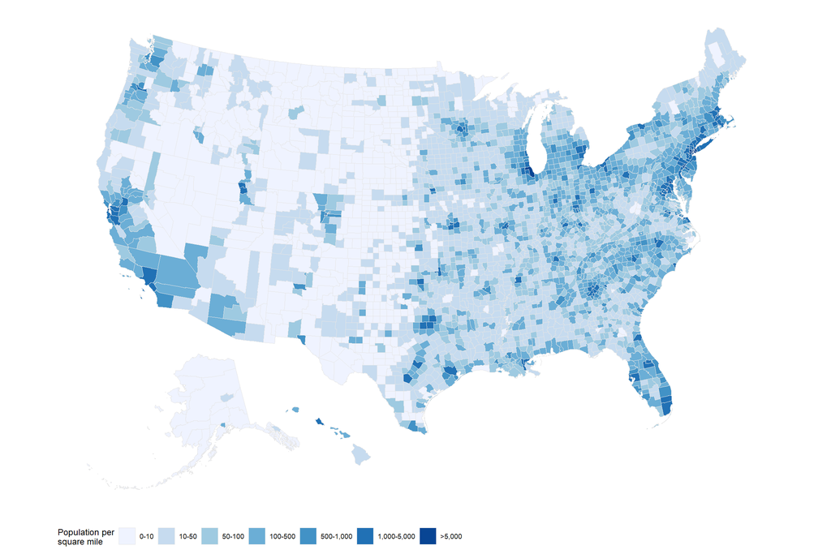

```r
p <- ggplot(data = county_full,
            mapping = aes(x = long, y = lat,
                          fill = pop_dens,
                          group = group))

p1 <- p + geom_polygon(color = "gray90", size = 0.05) + coord_equal()

p2 <- p1 + scale_fill_brewer(palette="Blues",
                             labels = c("0-10", "10-50", "50-100", "100-500",
                                        "500-1,000", "1,000-5,000", ">5,000"))

p2 + labs(fill = "Population per\nsquare mile") +
    theme_map() +
    guides(fill = guide_legend(nrow = 1)) +
    theme(legend.position = "bottom")
```

Desta vez vamos alterar a paleta do mapa para uma verde.

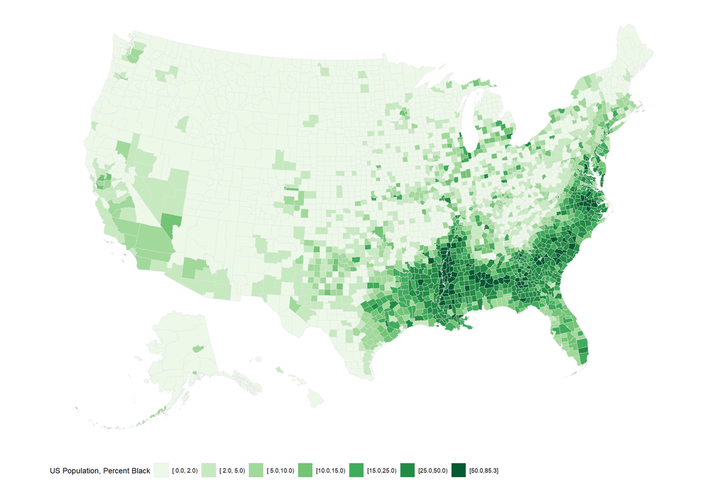

```r
p <- ggplot(data = county_full,
            mapping = aes(x = long,
                          y = lat,
                          fill = pct_black,
                          group = group))

p1 <- p + geom_polygon(color = "gray90", size = 0.05) + coord_equal()

p2 <- p1 + scale_fill_brewer(palette="Greens")

p2 + labs(fill = "US Population, Percent Black") +
    guides(fill = guide_legend(nrow = 1)) +
    theme_map() + theme(legend.position = "bottom")
```

Podemos definir novas paletas do pacote Color Brewer, observe que utilizamos a função rev() para inverter o vetor de cores.

```r
orange_pal <- RColorBrewer::brewer.pal(n = 6, name = "Oranges")
orange_pal
```

```
## [1] "#FEEDDE" "#FDD0A2" "#FDAE6B" "#FD8D3C" "#E6550D" "#A63603"
```

```r
orange_rev <- rev(orange_pal)
orange_rev
```

```
## [1] "#A63603" "#E6550D" "#FD8D3C" "#FDAE6B" "#FDD0A2" "#FEEDDE"
```

Agora aplicamos no mapa de densidade dos suicídios relacionados a armas a paleta customizada e a paleta invertida.

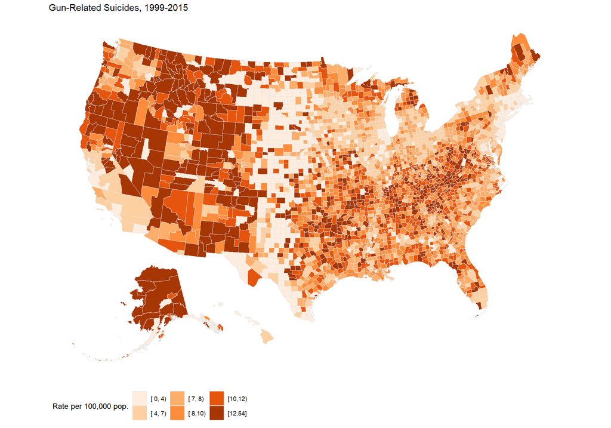

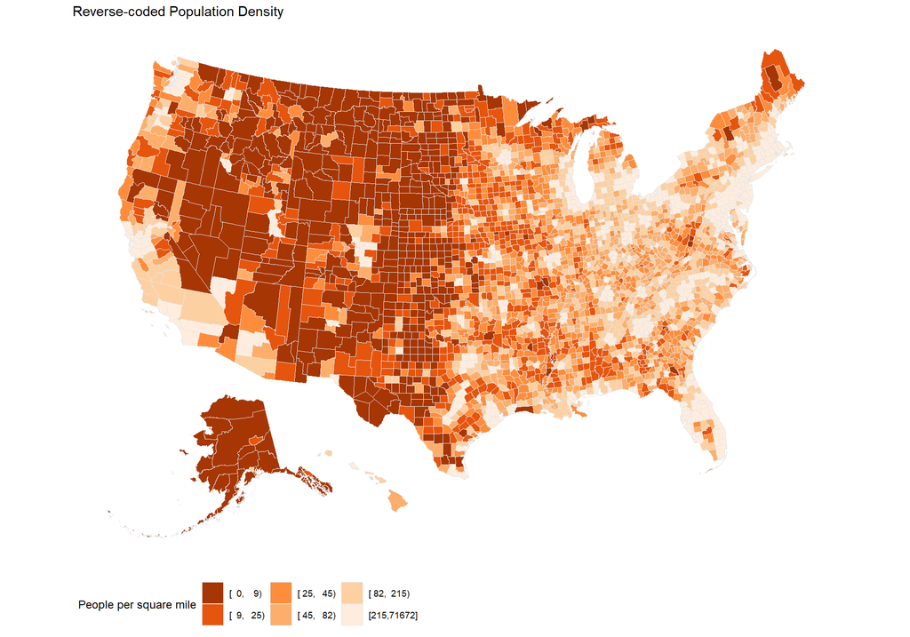

```r
gun_p <- ggplot(data = county_full,
            mapping = aes(x = long,
                          y = lat,
                          fill = su_gun6,
                          group = group))

gun_p1 <- gun_p + geom_polygon(color = "gray90", size = 0.05) + coord_equal()

gun_p2 <- gun_p1 + scale_fill_manual(values = orange_pal)

gun_p2 + labs(title = "Gun-Related Suicides, 1999-2015",
              fill = "Rate per 100,000 pop.") +
    theme_map() +
    theme(legend.position = "bottom")


pop_p <- ggplot(data = county_full,
            mapping = aes(x = long,
                          y = lat,
                          fill = pop_dens6,
                          group = group))

pop_p1 <- pop_p + geom_polygon(color = "gray90", size = 0.05) + coord_equal()

pop_p2 <- pop_p1 + scale_fill_manual(values = orange_rev)

pop_p2 + labs(title = "Reverse-coded Population Density",
              fill = "People per square mile") +
    theme_map() +
    theme(legend.position = "bottom")
```

## Statebins

Como uma alternativa, podemos considerar o pacote statebins:

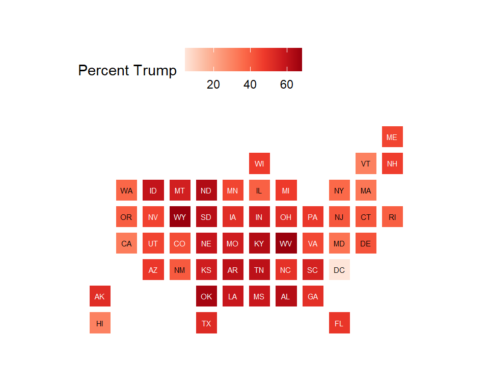

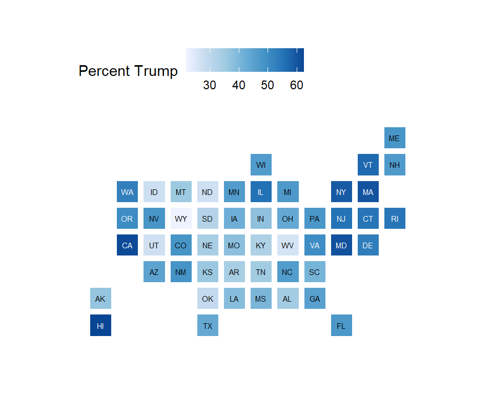

```r
statebins(election,
          state_col = "state",
          value_col = "pct_trump",
          name = "Percent Trump",
          palette = "Reds",
          direction = 1,
          font_size = 2) +
  theme_statebins(legend_position = "top")


statebins(state_data = subset(election, st %nin% "DC"),
          state_col = "state",
          value_col = "pct_clinton",
          name = "Percent Trump",
          palette = "Blues",
          direction = 1,
          font_size = 2) +
  theme_statebins(legend_position = "top")
```

## Múltiplos mapas

Múltiplos mapas é uma alternativa para representar dados geográficos ao longo do tempo. Utilizaremos o dataset opiates que foi dados sobre morte por drogas entre 1999 e 2014.

```r
opiates
```

```
## # A tibble: 800 x 11
##     year state    fips deaths population crude adjusted adjusted_se region abbr
##    <int> <chr>   <int>  <int>      <int> <dbl>    <dbl>       <dbl> <ord>  <chr>
##  1  1999 Alabama     1     37    4430141   0.8      0.8         0.1 South  AL
##  2  1999 Alaska      2     27     624779   4.3      4           0.8 West   AK
##  3  1999 Arizona     4    229    5023823   4.6      4.7         0.3 West   AZ
##  4  1999 Arkans~     5     28    2651860   1.1      1.1         0.2 South  AR
##  5  1999 Califo~     6   1474   33499204   4.4      4.5         0.1 West   CA
##  6  1999 Colora~     8    164    4226018   3.9      3.7         0.3 West   CO
##  7  1999 Connec~     9    151    3386401   4.5      4.4         0.4 North~ CT
##  8  1999 Delawa~    10     32     774990   4.1      4.1         0.7 South  DE
##  9  1999 Distri~    11     28     570213   4.9      4.9         0.9 South  DC
## 10  1999 Florida    12    402   15759421   2.6      2.6         0.1 South  FL
## # ... with 790 more rows, and 1 more variable: division_name <chr>
```

```r
opiates$region <- tolower(opiates$state)
opiates_map <- left_join(us_states, opiates)
```

Utilizaremos a paleta de cores do pacote viridis, que possui opções de cores balanceadas:

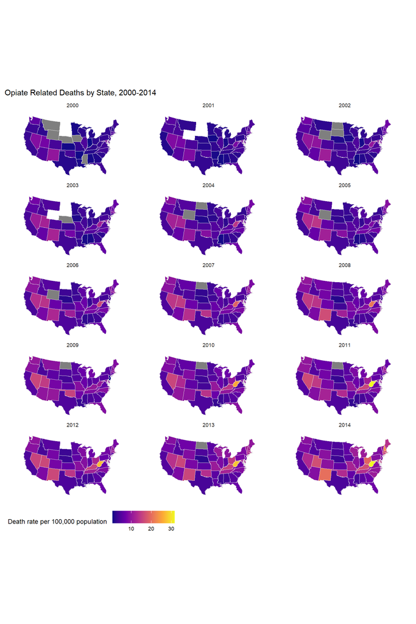

```r
library(viridis)

p0 <- ggplot(data = subset(opiates_map,
                           year > 1999),
             mapping = aes(x = long,
                           y = lat,
                           group = group,
                           fill = adjusted))

p1 <- p0 +
  geom_polygon(color = "gray90",
                        size = 0.05) +
  coord_map(projection = "albers",
            lat0 = 39,
            lat1 = 45)

p2 <- p1 + scale_fill_viridis_c(option = "plasma")

p2 + theme_map() +
  facet_wrap(~ year, ncol = 3) +
  theme(legend.position = "bottom",
        strip.background = element_blank()) +
  labs(fill = "Death rate per 100,000 population ",
       title = "Opiate Related Deaths by State, 2000-2014")
```